# ETC5521 Tutorial 5

Statistical inference for exploratory methods

Author

Prof. Di Cook

Published

August 24, 2023

## 🎯 Objectives

Learn to apply visual inference to different types of plots.

## 🔧 Preparation

The reading for this week is [Wickham et al. (2010) Graphical inference for Infovis](https://vita.had.co.nz/papers/inference-infovis.pdf). It is a basic introduction to inference for exploratory data analysis, especially for data visualisation. - Complete the weekly quiz, before the deadline! - Make sure you have this list of R packages installed:

```r
install.packages(c("tidyverse", "datarium", "broom", "nullabor"))
```

- Open your RStudio Project for this unit, (the one you created in week 1, `eda` or `ETC5521`). Create a `.Rmd` document for this week’s activities.

## Exercise 1: Skittles experiment

[figure not shown]

Skittles come in five colors (orange, yellow, red, purple, green) each with their own flavours (orange, lemon, strawberry, grape, green apple). [Data was collected by Dr Nick Tierney](https://github.com/njtierney/skittles/tree/master/data-raw) to explore whether a sample of 3 people could identify the flavour of skittles while blindfolded. You can find the cleaned tidy data [here](https://raw.githubusercontent.com/njtierney/skittles/master/data/skittles.csv).

1. How many skittles did each person taste?

**Solution**

```r
skittle <- read_csv("https://raw.githubusercontent.com/njtierney/skittles/master/data/skittles.csv")
```

Each person tasted 10 skittles.

```r
skittle %>%
  with(table(person))
```

```
person
 a  b  c
10 10 10
```

2. A person with loss of taste is called *ageusia* and a person who has a loss of smell is called *anosmia*. The loss of taste and loss of smell will not allow you to distinguish flavours in food. What is the probability that a person with ageusia and anosmia will guess the skittle flavour correctly (out of the five flavours) for one skittle?

**Solution**

If a person cannot distinguish flavours then they will randomly choose one of the five flavours. So the probability that they select the correct flavour is 1/5.

3. What is the probability that a person with ageusia and anosmia will guess the skittle flavour correctly for 2 out of 10 skittles, assuming the order of taste does not matter?

**Solution**

Suppose $X$ is the number of skittles that they correctly identified the flavour. Then assuming that the person cannot distinguish flavours and order of tasting the skittles does not matter, $X \sim B(10, 0.2)$. Then $P(X = 2) = {10 \choose 2} 0.2^2 0.8^8\approx 0.3$. So there’s only about 30% chance such an event happens!

```r
dbinom(2, 10, 0.2)
```

```
[1] 0.3019899
```

4. Test the null hypothesis that people cannot distinguish the flavours correctly, against the alternative that they can. Assume that the order of tasting does not matter and each person has the same ability to correctly identify the flavours. In conducting your test, define your null and alternate hypothesis, in statistical notation, your assumptions, the test statistics and calculate the $p$-value.

**Solution**

```r
sum(skittle$correct)
```

```
[1] 15
```

```r
1 - pbinom(sum(skittle$correct), 30, 0.2)
```

```
[1] 5.238729e-05
```

5. In part (d) we disregarded the order of the tasting and the possible variability in people’s ability to correctly identify the flavour. If in fact these do matter, then how would you construct the test statistic? Is it easy?

**Solution**

To construct a test statistic, we need to construct a summary statistic with some known distribution under the null hypothesis (if using a parametric approach) with large (or extreme) values indicating rejection of the null hypothesis. Suppose that $X_1$, $X_2$ and $X_3$ are the number of skittles out of 10 that person a, b and c, respectively, correctly identified. If each tasting is independent, then $X_1 \sim B(10, p_1)$, $X_2 \sim B(10, p_2)$ and $X_3 \sim B(10, p_3)$ where $p_i$ is the probability that the $i$-th person correctly identifies the flavour of a skittle. Now under $H_0$ you may assume that $p_1 = p_2 = p_3 = 0.2$ and assuming each person is independent, $X_1 + X_2 + X_3 \sim B(30, 0.2)$. Same as (d)! However, if we know remove the assumption that each tasting is independent (so the order of tasting does matter), then the distribution of the test statistic does not hold true any longer.

6. Consider the plot below that shows in each tile whether a person guessed correctly by order of their tasting. Suppose that under the null hypothesis, the order of tasting does not matter and people have no ability to distinguish the flavours. Generate a null plot under this null hypothesis.

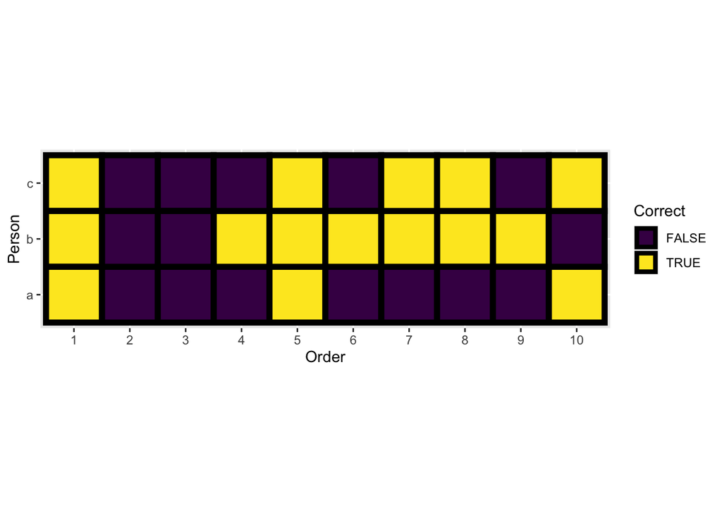

**Solution**

The null plot is constructed as follows.

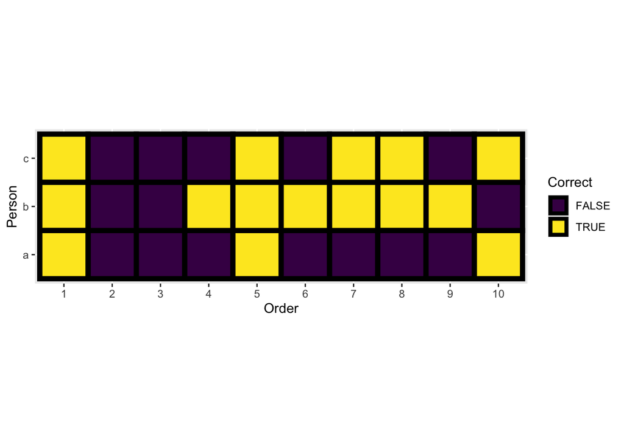

```r
gtile <- skittle %>%
  ggplot(aes(factor(order), person, fill = factor(correct))) +
  geom_tile(color = "black", size = 2) +
  coord_equal() +
  scale_fill_viridis_d() +
  labs(x = "Order", y = "Person", fill = "Correct")
gtile
```

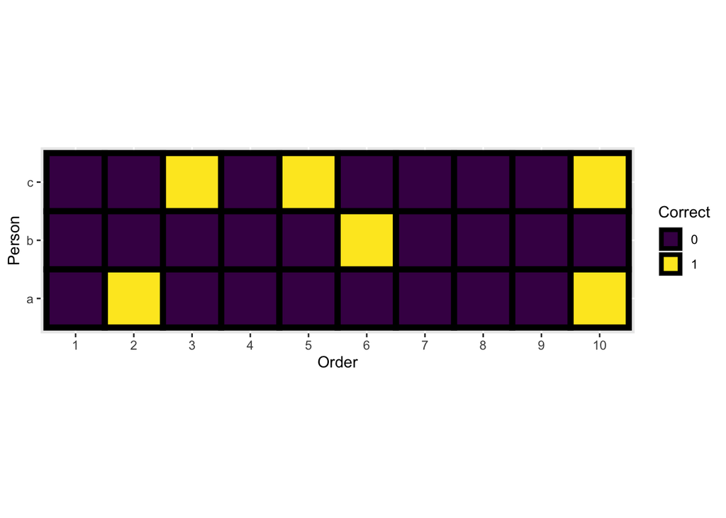

```r
set.seed(1)
method <- null_dist("correct", "binom", list(size = 1, prob = 0.2))
gtile %+% method(skittle)
```

7. Based on (f), construct a lineup (using `nullabor` or otherwise) of 20 plots. Ask your classmate, which plot looks different.

**Solution**

```r
lineup_df <- lineup(method, true = skittle)
```

```
decrypt("clZx bKhK oL 3OHohoOL 0C")
```

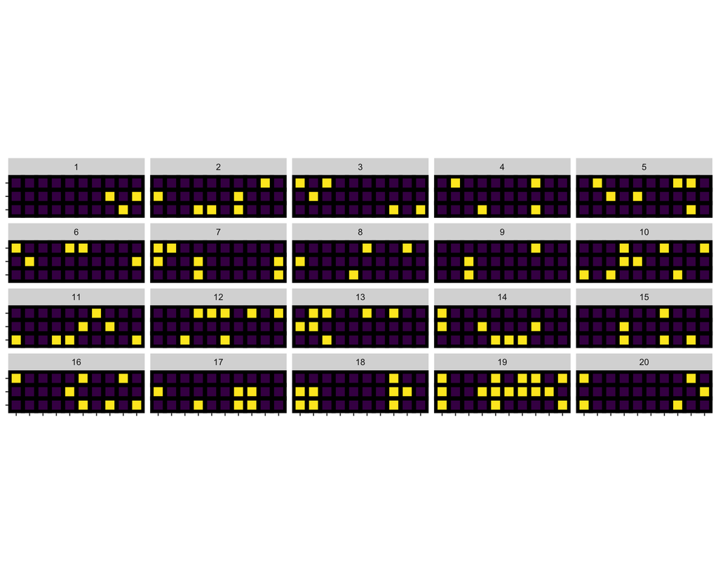

```r
gtile %+% lineup_df +
  facet_wrap(~.sample) +
  guides(fill = FALSE) +
  theme(axis.text = element_blank(),
        axis.title = element_blank())
```

```r
decrypt("h8RX 5IvI ne TAynvnAe YL")
```

[output not shown]

8. Suppose that you have a response from 100 people based on your line-up from (g) and 76 correctly identified the data plot. What is the $p$-value from this visual inference?

**Solution**

```r
1 - pbinom(75, 100, 0.05)
```

```
[1] 0
```

1. Now consider the plot below. Use the same null data in (g) to construct a lineup based on below visual statistic. Suppose we had 28 people out of 100 who correctly identified the data plot in this lineup. What is the difference in power of visual statistic in (f) and this one?

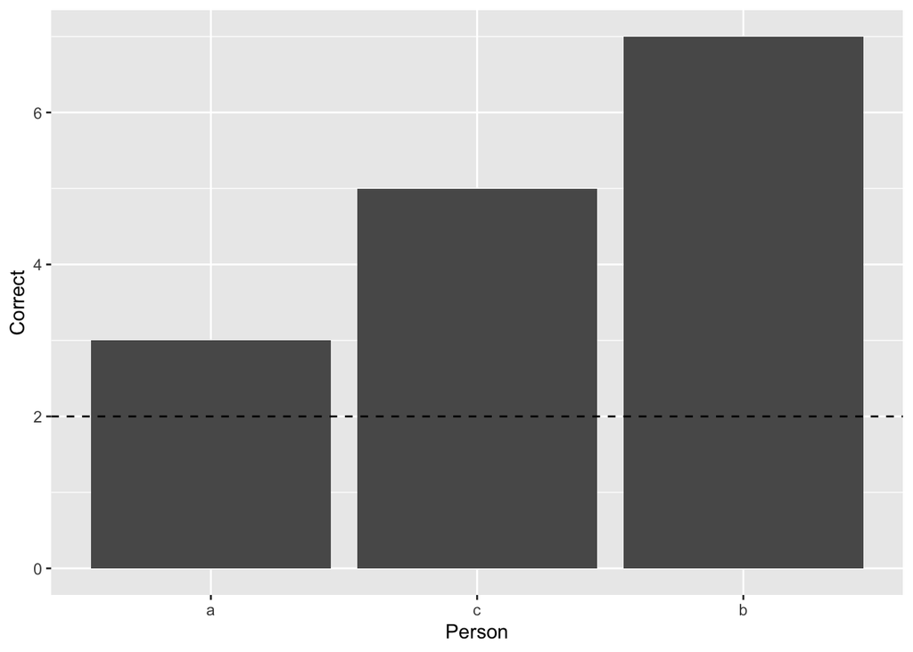

**Solution**

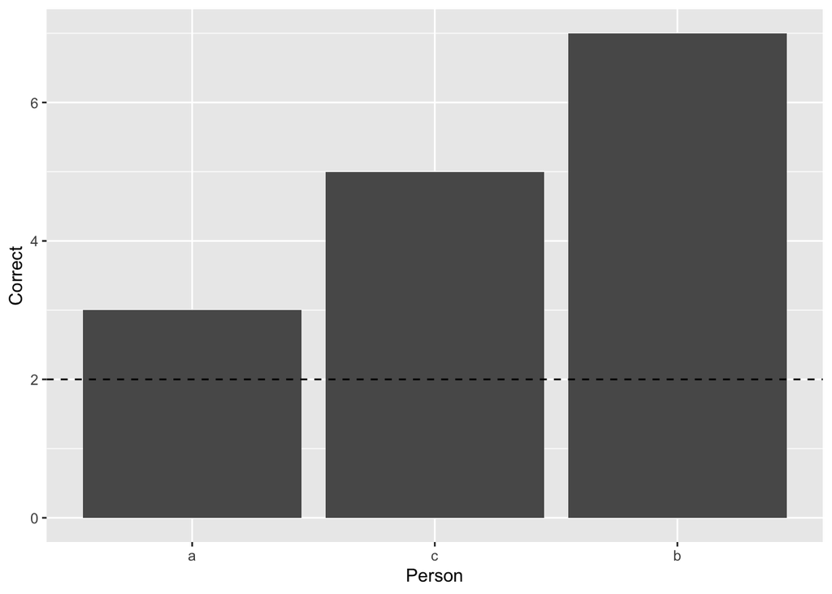

```r
gbar <- skittle %>%
  mutate(person = fct_reorder(person, correct, sum)) %>%
  group_by(person) %>%
  summarise(correct = sum(correct)) %>%
  ggplot(aes(person, correct)) +
  geom_col() +
  labs(x = "Person", y = "Correct") +
  geom_hline(yintercept = 2, linetype = "dashed")
gbar
```

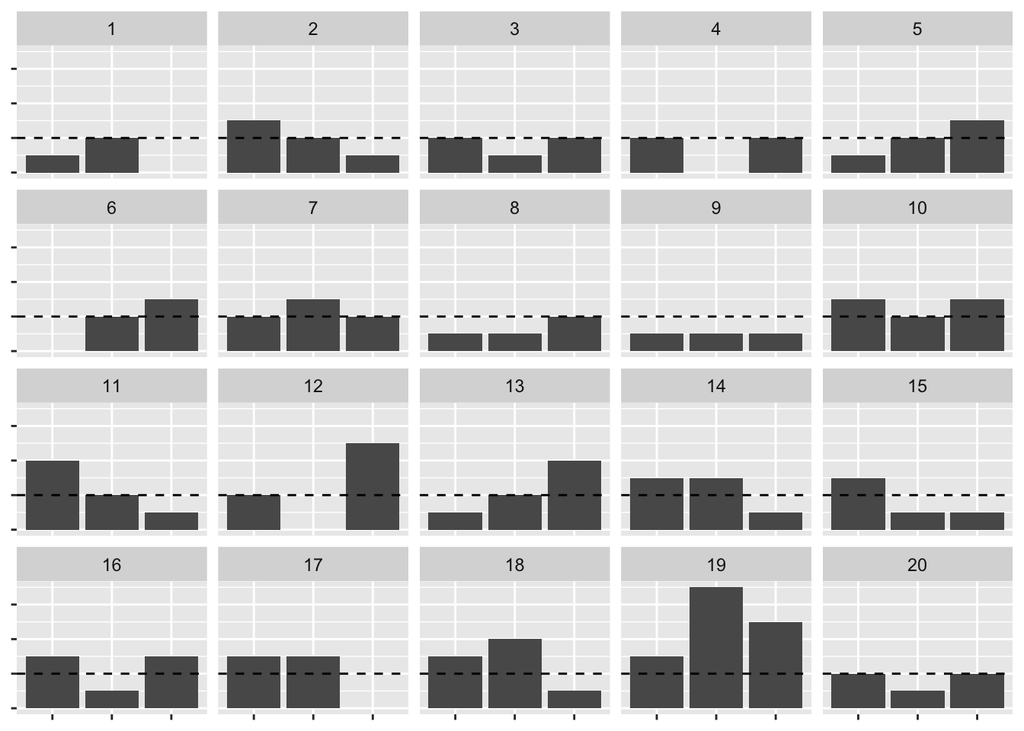

```r
gbar %+% lineup_df +
  facet_wrap(~.sample) +
  guides(fill = FALSE) +
  theme(axis.text = element_blank(),
        axis.title = element_blank())
```

```r
decrypt("h8RX 5IvI ne TAynvnAe YL")
```

[output not shown]

## Exercise 2: Social media marketing

The data `marketing` in the `datarium` R-package contains information on sales with advertising budget for three advertising media (youtube, facebook and newspaper). This advertising experiment was repeated 200 times to study the impact of the advertisting media on sales.

```r
data(marketing, package = "datarium")
```

1. Study the pairs plot. Which of the advertising medium do you think affects the sales?

**Solution**

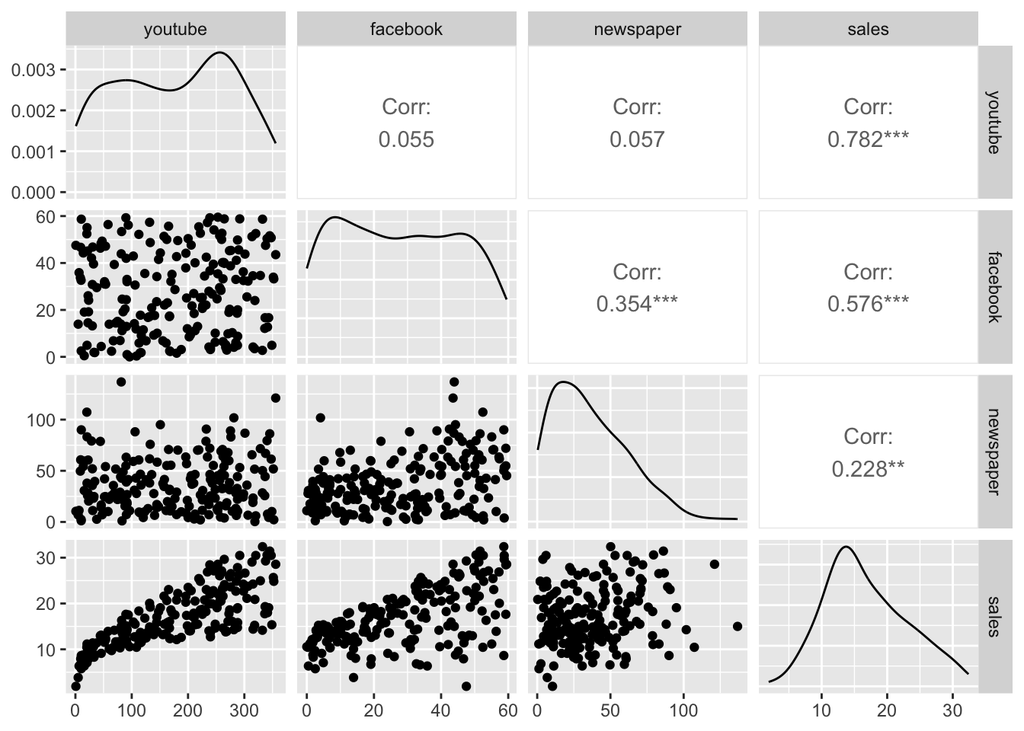

```r
GGally::ggpairs(marketing)
```

The pairs plot suggest that advertising on youtube is highly correlated with the sales and advertising on facebook is moderately correlated with the sales. Newspaper advertisement does not appear to be correlated highly with the sales.

2. Construct a coplot for sales vs advertising budget for facebook conditioned on advertising budget for youtube and newspaper. (You may like to make the intervals non-overlapping to make it easier to plot in `ggplot`). What do you see in the plot?

**Solution**

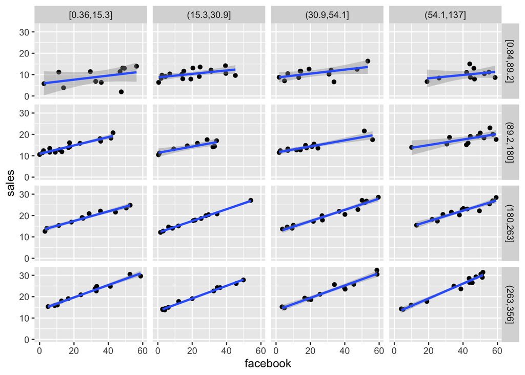

```r
marketing %>%
  ggplot(aes(facebook, sales)) +
  geom_point() +
  facet_grid(cut_number(youtube, 4) ~ cut_number(newspaper, 4)) +
  geom_smooth(method = "lm")
```

The newspaper does not seem to have much affect on the sales however it is noticeable that sales is linearly related to advertisement budget for facebook conditioned on youtube.

3. Now construct a coplot for sales vs advertising budget for facebook conditioned on advertising budget for youtube alone. Superimpose a linear model on each facet. Is there an interval where the linear model is not a good fit?